# RAC_All_Tract

David J Degnan

5/20/2022

## Brief Description

RAC - Resident Area Characteristic Data - totaled by HOME census block

Both federal and non-federal datasets were combined.

## Subset and Roll Up

Subset to the 2015-2018 years and roll up to the county level.

## Get Proportions

*Total:* C000 Num Total number of jobs

*Age*

- CA01 Num Number of jobs for workers age 29 or younger
- CA02 Num Number of jobs for workers age 30 to 54
- CA03 Num Number of jobs for workers age 55 or older

*Earnings*

- CE01 Num Number of jobs with earnings 1250/month or less
- CE02 Num Number of jobs with earnings 1251/month to 3333/month
- CE03 Num Number of jobs with earnings greater than 3333/month

*Industry*

- CNS01 Num Number of jobs in NAICS sector 11 (Agriculture, Forestry, Fishing and Hunting)
- CNS02 Num Number of jobs in NAICS sector 21 (Mining, Quarrying, and Oil and Gas Extraction)
- CNS03 Num Number of jobs in NAICS sector 22 (Utilities)
- CNS04 Num Number of jobs in NAICS sector 23 (Construction)
- CNS05 Num Number of jobs in NAICS sector 31-33 (Manufacturing)
- CNS06 Num Number of jobs in NAICS sector 42 (Wholesale Trade)
- CNS07 Num Number of jobs in NAICS sector 44-45 (Retail Trade)
- CNS08 Num Number of jobs in NAICS sector 48-49 (Transportation and Warehousing)
- CNS09 Num Number of jobs in NAICS sector 51 (Information)
- CNS10 Num Number of jobs in NAICS sector 52 (Finance and Insurance)
- CNS11 Num Number of jobs in NAICS sector 53 (Real Estate and Rental and Leasing)
- CNS12 Num Number of jobs in NAICS sector 54 (Professional, Scientific, and Technical Services)
- CNS13 Num Number of jobs in NAICS sector 55 (Management of Companies and Enterprises)
- CNS14 Num Number of jobs in NAICS sector 56 (Administrative and Support and Waste Management and * Remediation Services)
- CNS15 Num Number of jobs in NAICS sector 61 (Educational Services)
- CNS16 Num Number of jobs in NAICS sector 62 (Health Care and Social Assistance)
- CNS17 Num Number of jobs in NAICS sector 71 (Arts, Entertainment, and Recreation)
- CNS18 Num Number of jobs in NAICS sector 72 (Accommodation and Food Services)
- CNS19 Num Number of jobs in NAICS sector 81 (Other Services [except Public Administration])
- CNS20 Num Number of jobs in NAICS sector 92 (Public Administration)

*Race*

- CR01 Num Number of jobs for workers with Race: White, Alone (split out Hispanic)
- CR02 Num Number of jobs for workers with Race: Black or African American Alone
- CR03 Num Number of jobs for workers with Race: American Indian or Alaska Native Alone
- CR04 Num Number of jobs for workers with Race: Asian Alone
- CR05 Num Number of jobs for workers with Race: Native Hawaiian or Other Pacific Islander Alone
- CR07 Num Number of jobs for workers with Race: Two or More Race Groups

*Ethnicity*

- CT01 Num Number of jobs for workers with Ethnicity: Not Hispanic or Latino
- CT02 Num Number of jobs for workers with Ethnicity: Hispanic or Latino

*Education*

- CD01 Num Number of jobs for workers with Educational Attainment: Less than high school
- CD02 Num Number of jobs for workers with Educational Attainment: High school or equivalent, no college
- CD03 Num Number of jobs for workers with Educational Attainment: Some college or Associate degree
- CD04 Num Number of jobs for workers with Educational Attainment: Bachelor’s degree or advanced degree

*Sex*

- CS01 Num Number of jobs for workers with Sex Male
- CS02 Num Number of jobs for workers with Sex Female

|  | Column | Description |
| --- | --- | --- |
| 1 | ca01 | Age 14 to 29 |
| 2 | ca02 | Age 30 to 54 |
| 3 | ca03 | Age 55 and Older |
| 4 | ce01 | Earning 1250 or less |
| 5 | ce02 | Earning 1250 to 3333 |
| 6 | ce03 | Earning 3333 or more |
| 7 | cns01 | Agriculture |
| 8 | cns02 | Mining |
| 9 | cns03 | Utilities |
| 10 | cns04 | Construction |

[output cut: 30 more lines]

## County Sizes

```
##    Min. 1st Qu.  Median    Mean 3rd Qu.    Max.
##     130    4262   10277   45016   28137 4353436
```

## Jobs per…

We have 3142 samples.

#### Age

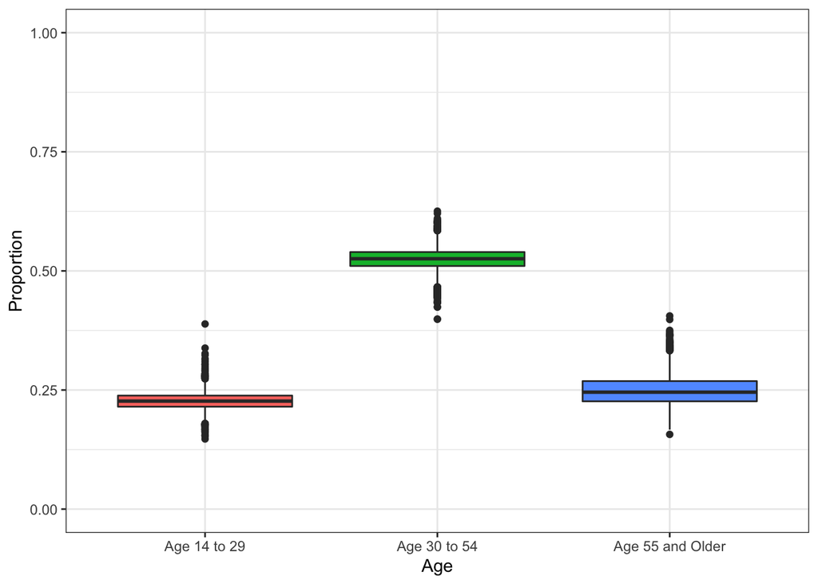

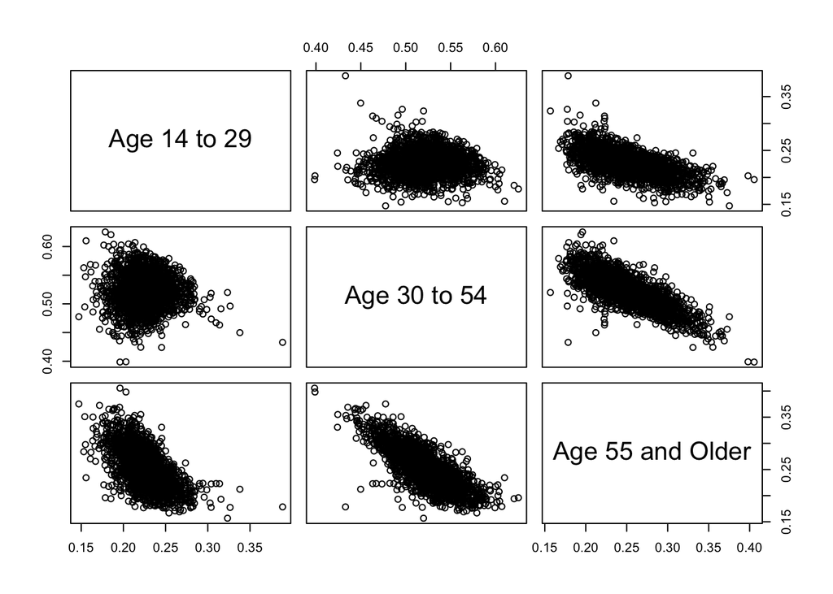

#### Earnings

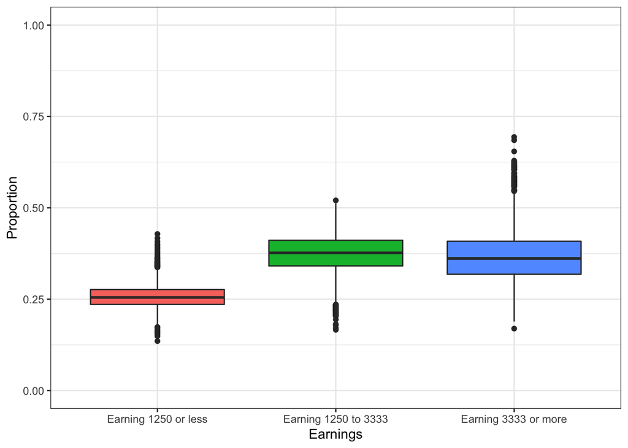

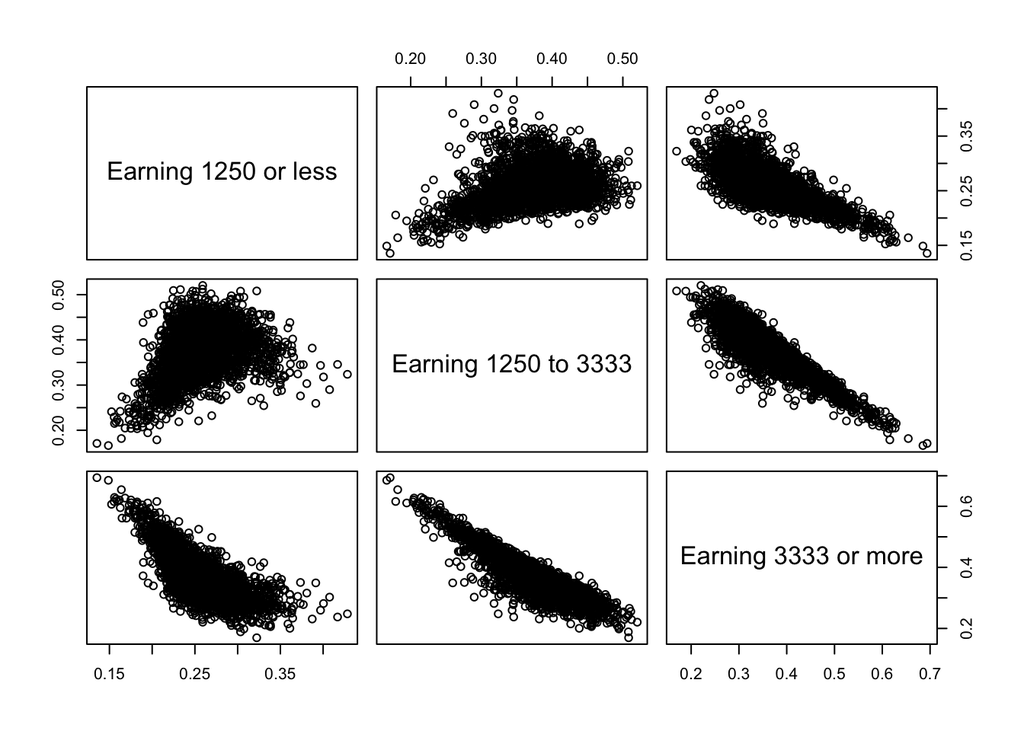

#### Industry

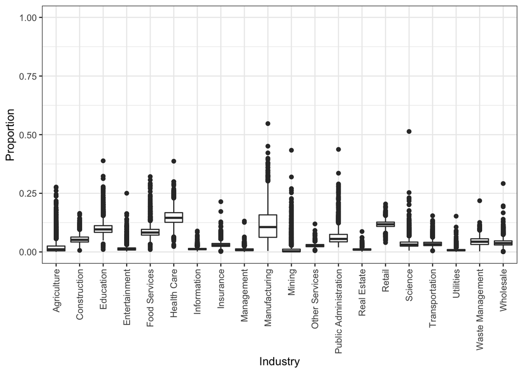

#### Race

Since we are counting Hispanic as a race in this case, we will calculate Hispanic as Hispanic Ethnicity Proportion * White Race Proportion, and adjust White Race Proportion to be Not Hispanic Ethnicity Proportion * White Race Proportion.

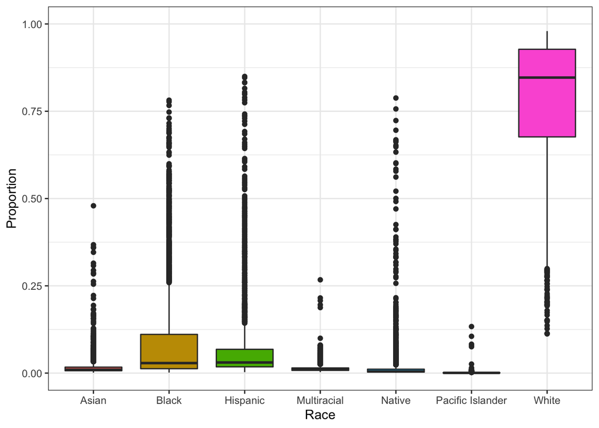

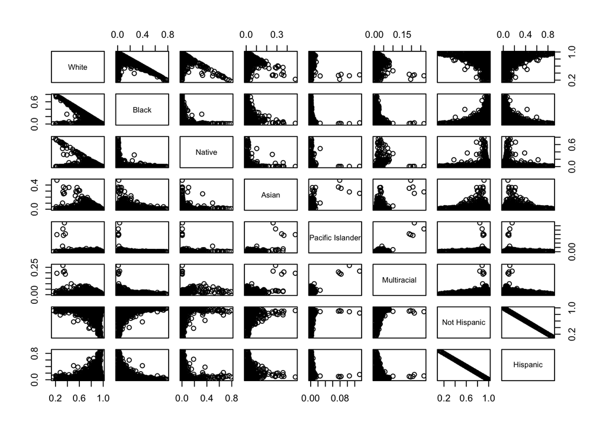

#### Education

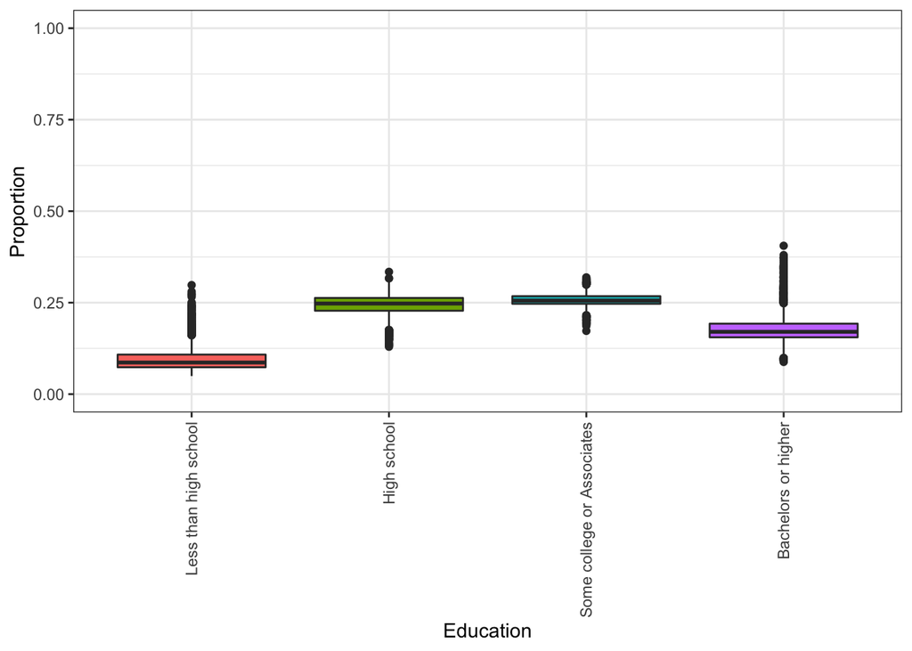

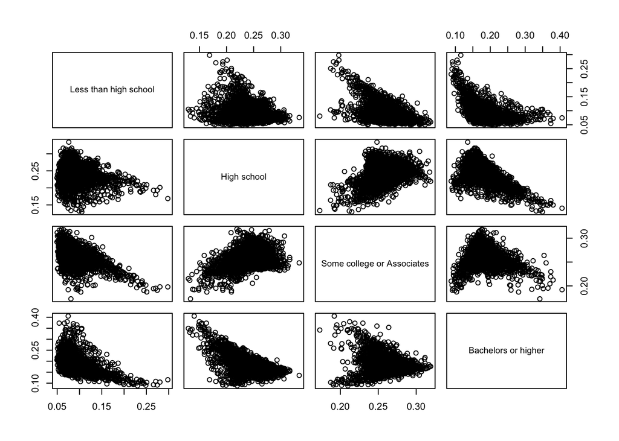

#### Sex

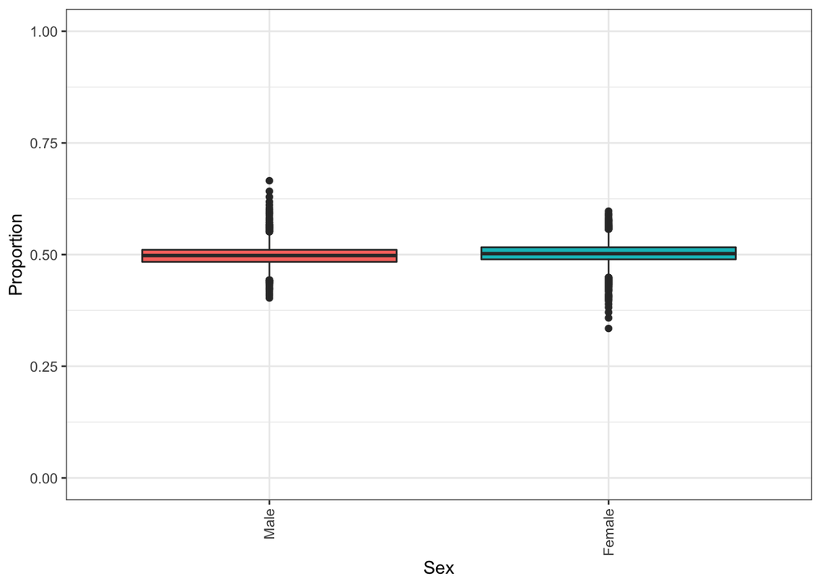

## Outlier Detection

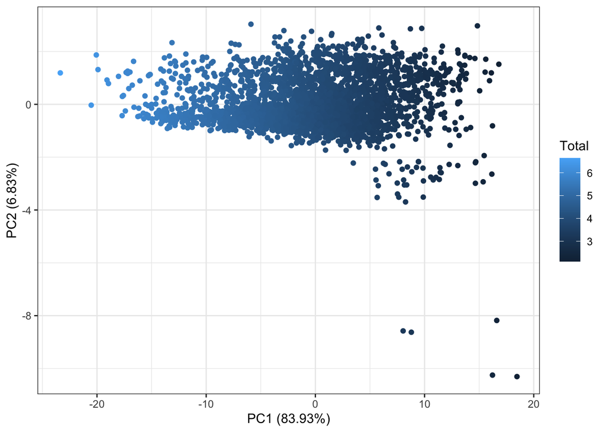

|  | FIPS | c000 | ca01 | ca02 | ca03 | ce01 | ce02 | ce03 | cns01 | cns02 | cns03 | cns04 | cns05 | cns06 | cns07 | cns08 | cns09 | cns10 | cns11 | cns12 | cns13 | cns14 | cns15 | cns16 | cns17 | cns18 | cns19 | cns20 | cr01 | … |
| --- | --- | --- | --- | --- | --- | --- | --- | --- | --- | --- | --- | --- | --- | --- | --- | --- | --- | --- | --- | --- | --- | --- | --- | --- | --- | --- | --- | --- | --- | --- |
| 1 | 31005 | 150 | 32 | 65 | 53 | 52 | 56.75 | 41.25 | 15 | 0 | 0.75 | 7 | 6.25 | 8.75 | 16.25 | 4 | 1.75 | 2 | 0.5 | 7.25 | 0.75 | 2.25 | 34.75 | 11.75 | 1.25 | 10.75 | 1.25 | 17.75 | 144.5 | … |
| 2 | 31009 | 205.25 | 45.75 | 94.25 | 65.25 | 65 | 83.5 | 56.75 | 28 | 0 | 0.25 | 9 | 11.5 | 9.5 | 17.5 | 4.25 | 2.25 | 8.5 | 0.75 | 9 | 2 | 2.25 | 30.75 | 25 | 2 | 12.25 | 2 | 28.5 | 196.5 | … |
| 3 | 31091 | 282 | 57.25 | 112.5 | 112.25 | 105.25 | 97.25 | 79.5 | 12.75 | 0 | 0.5 | 7 | 7.5 | 10.25 | 30.75 | 8.25 | 0.75 | 6.75 | 2.5 | 3.25 | 1.75 | 2.75 | 61 | 45.25 | 30.75 | 12.75 | 4.75 | 32.75 | 272.75 | … |
| 4 | 37095 | 1727.25 | 338 | 872 | 517.25 | 563 | 720.75 | 443.5 | 110.75 | 0 | 11.5 | 91.5 | 85 | 95.5 | 262.75 | 42.75 | 10.5 | 27.5 | 39.75 | 34.25 | 12.25 | 53.5 | 193.5 | 175.5 | 15.5 | 219.25 | 34.75 | 211.25 | 1223.25 | … |
| 5 | 37177 | 1421.5 | 292 | 732.75 | 396.75 | 423.25 | 631.5 | 366.75 | 93.25 | 0 | 3 | 75.75 | 85.5 | 48 | 203.5 | 26.5 | 10.25 | 22.75 | 35 | 30.5 | 9 | 59.25 | 195.25 | 125 | 14.75 | 149.25 | 71.5 | 163.5 | 920 | … |